# Problem Set 3

### 4.4c

The residuals still show a clear pattern over time and the ACF remains high across many months, so they don’t look like white noise and the Ljung–Box test confirms this, with a p-value extremely close to zero (below 0.05) . This means I can reject the null hypothesis of no autocorrelation and conclude that the model is still missing some important patterns in the data

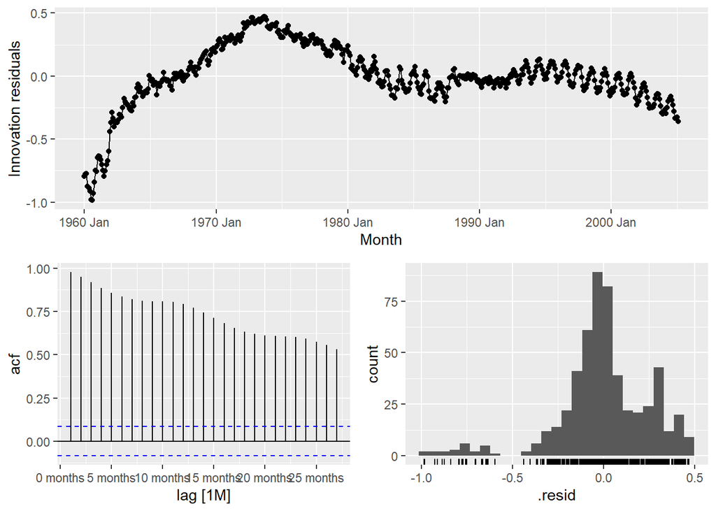

```r
# Residual diagnostic plots
can_gas_fit |>
  gg_tsresiduals()
```

```r
# Ljung-Box test using 24 lags
can_gas_fit |>
  augment() |>
  features(.innov, ljung_box, lag = 24) |>
  knitr::kable(digits = 3)
```

| .model | lb_stat | lb_pvalue |
| --- | --- | --- |
| TSLM(log_volume ~ trend() + season()) | 7774.218 | 0 |

### 5.1a

I compared the two models using an expanding window, with forecasts evaluated from January 1980 to February 2005. The SNAIVE model performed much better, with an MAE of 0.562 and an RMSE of 0.702, compared to 4.01 and 4.36 for TSLM. Both measures agree that SNAIVE is more accurate, which means that using production from the same month of the previous year works better than relying on a simple linear trend and seasonal model

```r
# Expanding-window cross-validation
gas_cv_fc <- can_gas |>
  select(Month, Volume) |>
  stretch_tsibble(.init = 240, .step = 1) |>
  model(
    snaive = SNAIVE(Volume),
    tslm = TSLM(log(Volume) ~ trend() + season())
  ) |>
  forecast(h = 1)

# Forecast accuracy table
gas_cv_fc |>
  accuracy(
    can_gas,
    measures = list(MAE = MAE, RMSE = RMSE)
  ) |>
  as_tibble() |>
  select(.model, MAE, RMSE) |>
  knitr::kable(digits = 3)
```

| .model | MAE | RMSE |
| --- | --- | --- |
| snaive | 0.562 | 0.702 |
| tslm | 4.009 | 4.362 |

### 5.2a

The Diebold–Mariano test gives a statistic of -31.278 and a p-value below 2.2 × 10⁻¹⁶, which is much smaller than 0.05. This means I can reject the idea that the two models have equal forecast accuracy. Together with the previous results, this confirms that SNAIVE performs significantly better than TSLM when predicting Canadian gas production

```r
# Calculate forecast errors
errs <- gas_cv_fc |>
  as_tibble() |>
  left_join(
    can_gas |>
      select(Month, actual = Volume),
    by = "Month"
  ) |>
  mutate(e = actual - .mean) |>
  select(Month, .model, e) |>
  pivot_wider(
    names_from = .model,
    values_from = e
  ) |>
  na.omit()

# Diebold-Mariano test
dm_result <- forecast::dm.test(
  errs$snaive,
  errs$tslm,
  h = 1,
  power = 1
)

# Display results as a table
data.frame(
  "DM statistic" = round(unname(dm_result$statistic), 3),
  "p-value" = format.pval(dm_result$p.value, digits = 3),
  check.names = FALSE
) |>
  knitr::kable()
```

| DM statistic | p-value |
| --- | --- |
| -31.278 | <2e-16 |

### 5.3a

Switching to a rolling window improved the TSLM model quite a lot. Its MAE decreased from 4.01 to 2.09, while its RMSE went from 4.36 to 2.42. On the other hand, SNAIVE’s results stayed exactly the same. I think TSLM improved more because using recent data helps it follow changes in the growth trend, instead of relying on older observations that may no longer represent the current pattern

```r
# Rolling-window cross-validation
gas_roll_fc <- can_gas |>
  select(Month, Volume) |>
  slide_tsibble(.size = 240, .step = 1) |>
  model(
    snaive = SNAIVE(Volume),
    tslm = TSLM(log(Volume) ~ trend() + season())
  ) |>
  forecast(h = 1)

# Rolling-window forecast accuracy
gas_roll_fc |>
  accuracy(
    can_gas,
    measures = list(MAE = MAE, RMSE = RMSE)
  ) |>
  as_tibble() |>
  select(.model, MAE, RMSE) |>
  knitr::kable(digits = 3)
```

| .model | MAE | RMSE |
| --- | --- | --- |
| snaive | 0.562 | 0.702 |
| tslm | 2.095 | 2.425 |

### Reflection

Finally, the residual plots showed that the trend and seasonal model was still missing some patterns in Canadian gas production and the Ljung–Box test confirmed this, since the p-value was below 0.05, meaning the residuals were not behaving like white noise.

I also found it interesting that SNAIVE performed much better than TSLM, although this last one improved quite a bit when I then switched to a rolling window. This probably tell us that the simple linear trend was not flexible enough to capture how gas production changed over time. Because of that, I think a better forecasting model would pay more attention to recent observations and past changes rather than assuming the same growth trend throughout the entire period